# M.Gameel

## Dataset overview:

Historical sales data for 45 stores located in different regions - each store contains a number of departments. The company also runs several promotional markdown events throughout the year. These markdowns precede prominent holidays

the data consists of three files:

- Features:Contains additional data related to the store, department, and regional activity for the given dates.
- Sales:Historical sales data
- Stores:Anonymized information about the 45 stores, indicating the type and size of store

I got this data from Kaggle [Retail Data Analytics](https://www.kaggle.com/manjeetsingh/retaildataset/home)

```
## [1] "E:/knowledge/online learning/DAND/EDA/project"
```

```r
# Load the Data
features = read.csv("Features data set.csv")
sales = read.csv("sales data-set.csv")
stores = read.csv("stores data-set.csv")

#joining data
data = inner_join(sales, stores , by = "Store")
data = inner_join(data , features , by = c("Store" , "Date"))

#examine the data
str(data)
```

```
## 'data.frame':    421570 obs. of  17 variables:
##  $ Store       : int  1 1 1 1 1 1 1 1 1 1 ...
##  $ Dept        : int  1 1 1 1 1 1 1 1 1 1 ...
##  $ Date        : chr  "05/02/2010" "12/02/2010" "19/02/2010" "26/02/2010" ...
##  $ Weekly_Sales: num  24925 46039 41596 19404 21828 ...
##  $ IsHoliday.x : logi  FALSE TRUE FALSE FALSE FALSE FALSE ...
##  $ Type        : Factor w/ 3 levels "A","B","C": 1 1 1 1 1 1 1 1 1 1 ...
##  $ Size        : int  151315 151315 151315 151315 151315 151315 151315 151315 151315 151315 ...
##  $ Temperature : num  42.3 38.5 39.9 46.6 46.5 ...
##  $ Fuel_Price  : num  2.57 2.55 2.51 2.56 2.62 ...
##  $ MarkDown1   : num  NA NA NA NA NA NA NA NA NA NA ...
##  $ MarkDown2   : num  NA NA NA NA NA NA NA NA NA NA ...
##  $ MarkDown3   : num  NA NA NA NA NA NA NA NA NA NA ...
##  $ MarkDown4   : num  NA NA NA NA NA NA NA NA NA NA ...
##  $ MarkDown5   : num  NA NA NA NA NA NA NA NA NA NA ...
##  $ CPI         : num  211 211 211 211 211 ...
##  $ Unemployment: num  8.11 8.11 8.11 8.11 8.11 ...
##  $ IsHoliday.y : logi  FALSE TRUE FALSE FALSE FALSE FALSE ...
```

```r
#check if holdiies columns are the same and then drop one
table(data$IsHoliday.x == data$IsHoliday.y)
```

```
##
##   TRUE
## 421570
```

```r
data = data[,names(data) != "IsHoliday.y"]

#change some column names
new_names = names(data)
new_names[5] = "IsHoliday"
new_names[6] = "Store_Type"
new_names[7] = "Store_Size"
names(data) = new_names

#change some data types
data$Date = as.Date(data$Date,"%d/%m/%Y")
data$Store = as.factor(data$Store)
data$Dept = as.factor(data$Dept)


#sum all markdowns in one column
data$Markdown = data$MarkDown1 + data$MarkDown2 + data$MarkDown3 + data$MarkDown4 + data$MarkDown5
data[is.na(data$Markdown),"Markdown"] = 0

#drop unnecessary  columns
data = data[,!names(data) %in% c("MarkDown1","MarkDown2","MarkDown3","MarkDown4","MarkDown5")]

#aggregate to get all Departments' sales

data = data %>% group_by(Date,Store,Store_Type,Store_Size,Temperature,Fuel_Price,CPI,Unemployment,
                         IsHoliday,Markdown) %>%
  summarise(Weekly_Sales = sum(Weekly_Sales))

#export as a backup
write.csv(data , "clean_sales.csv")
```

# Univariate Plots Section

### the sahpe of data:

```
## [1] 6435   11
```

Data consists of 6435 observations with 11 variables.

### data structure and summary

```
## Classes 'grouped_df', 'tbl_df', 'tbl' and 'data.frame':  6435 obs. of  11 variables:
##  $ Date        : Date, format: "2010-02-05" "2010-02-05" ...
##  $ Store       : Factor w/ 45 levels "1","2","3","4",..: 1 2 3 4 5 6 7 8 9 10 ...
##  $ Store_Type  : Factor w/ 3 levels "A","B","C": 1 1 2 1 2 1 2 1 2 2 ...
##  $ Store_Size  : int  151315 202307 37392 205863 34875 202505 70713 155078 125833 126512 ...
##  $ Temperature : num  42.3 40.2 45.7 43.8 39.7 ...
##  $ Fuel_Price  : num  2.57 2.57 2.57 2.6 2.57 ...
##  $ CPI         : num  211 211 214 126 212 ...
##  $ Unemployment: num  8.11 8.32 7.37 8.62 6.57 ...
##  $ IsHoliday   : logi  FALSE FALSE FALSE FALSE FALSE FALSE ...
##  $ Markdown    : num  0 0 0 0 0 0 0 0 0 0 ...
##  $ Weekly_Sales: num  1643691 2136989 461622 2135144 317173 ...
##  - attr(*, "vars")= chr  "Date" "Store" "Store_Type" "Store_Size" ...
##  - attr(*, "drop")= logi TRUE
```

```
##       Date                Store      Store_Type   Store_Size
##  Min.   :2010-02-05   1      : 143   A:3146     Min.   : 34875
##  1st Qu.:2010-10-08   2      : 143   B:2431     1st Qu.: 70713
##  Median :2011-06-17   3      : 143   C: 858     Median :126512
##  Mean   :2011-06-17   4      : 143              Mean   :130288
##  3rd Qu.:2012-02-24   5      : 143              3rd Qu.:202307
##  Max.   :2012-10-26   6      : 143              Max.   :219622
##                       (Other):5577
##   Temperature       Fuel_Price         CPI         Unemployment
##  Min.   : -2.06   Min.   :2.472   Min.   :126.1   Min.   : 3.879
##  1st Qu.: 47.46   1st Qu.:2.933   1st Qu.:131.7   1st Qu.: 6.891
##  Median : 62.67   Median :3.445   Median :182.6   Median : 7.874
##  Mean   : 60.66   Mean   :3.359   Mean   :171.6   Mean   : 7.999
##  3rd Qu.: 74.94   3rd Qu.:3.735   3rd Qu.:212.7   3rd Qu.: 8.622
##  Max.   :100.14   Max.   :4.468   Max.   :227.2   Max.   :14.313
##
##  IsHoliday          Markdown       Weekly_Sales
##  Mode :logical   Min.   :     0   Min.   : 209986
##  FALSE:5985      1st Qu.:     0   1st Qu.: 553350
##  TRUE :450       Median :     0   Median : 960746
##                  Mean   :  5072   Mean   :1046965
##                  3rd Qu.:     0   3rd Qu.:1420159
##                  Max.   :160511   Max.   :3818686
##
```

- **Date**: the period of our investigation which starts at 5/2/2010 and ends at 26/10/2012 on week bases
- **Store** : factor of 45 stores from different regions
- **Store_type** : categorical variable of the levels A , B , c .indicates the level of store

### store_size

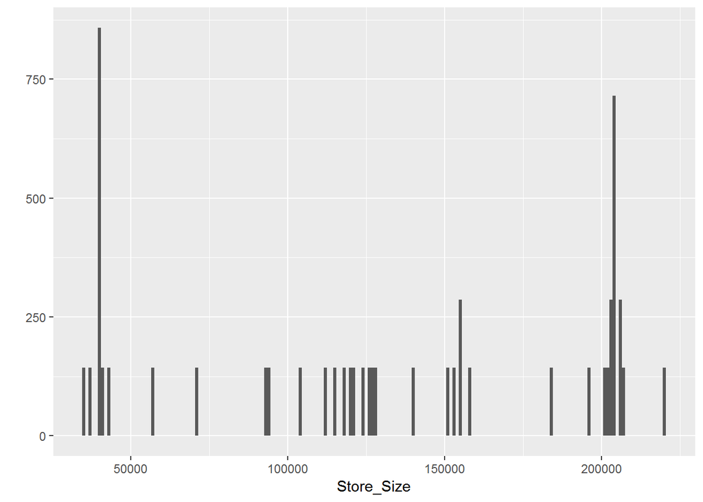

```
##    Min. 1st Qu.  Median    Mean 3rd Qu.    Max.
##   34875   70713  126512  130288  202307  219622
```

tabling of the store size:

```
##
##  34875  37392  39690  39910  41062  42988  57197  70713  93188  93638
##    143    143    429    429    143    143    143    143    143    143
## 103681 112238 114533 118221 119557 120653 123737 125833 126512 128107
##    143    143    143    143    143    143    143    143    143    143
## 140167 151315 152513 155078 155083 158114 184109 196321 200898 202307
##    143    143    143    143    143    143    143    143    143    143
## 202505 203007 203742 203750 203819 204184 205863 206302 207499 219622
##    143    143    143    143    286    143    143    143    143    143
```

Note that the values are multiplicate of 143 which is the number of weeks in our investigation

### Temperature

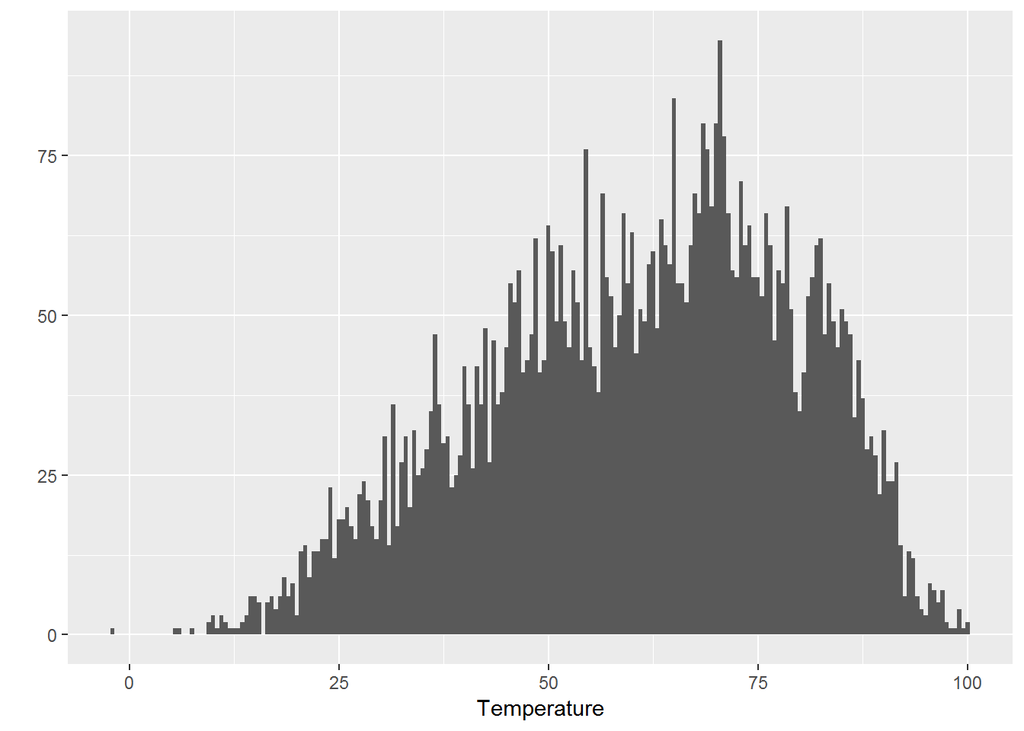

```
##    Min. 1st Qu.  Median    Mean 3rd Qu.    Max.
##   -2.06   47.46   62.67   60.66   74.94  100.14
```

looks like we have a good range of temperatures resulting from different store locations and different times of the year.I wonder what the sales look like in low temperature.

### Fuel_price:

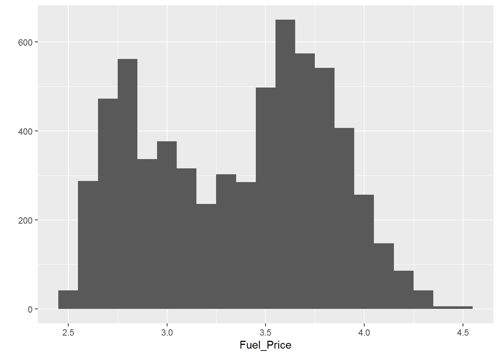

```
##    Min. 1st Qu.  Median    Mean 3rd Qu.    Max.
##   2.472   2.933   3.445   3.359   3.735   4.468
```

the values of fuel prices range feom 2.5 to 4.5 .I wonder does the fuel price has an effect on sales

### The Consumer Price Index (CPI):

**First a small introduction to this measure :** The Consumer Price Index (CPI) is a measure that examines the weighted average of prices of a basket of consumer goods and services, such as transportation, food and medical care. It is calculated by taking price changes for each item in the predetermined basket of goods and averaging them. Changes in the CPI are used to assess price changes associated with the cost of living; the CPI is one of the most frequently used statistics for identifying periods of inflation or deflation.

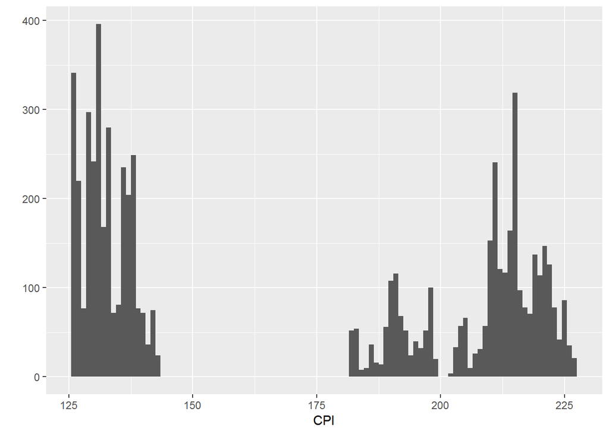

```
##    Min. 1st Qu.  Median    Mean 3rd Qu.    Max.
##   126.1   131.7   182.6   171.6   212.7   227.2
```

The CPI varies from 126 to 226 .There is a region of discontinuity between 140 to 180 approximately .this indicates tha we don’t have stores with citys in that area of CPI.

### Unemployment

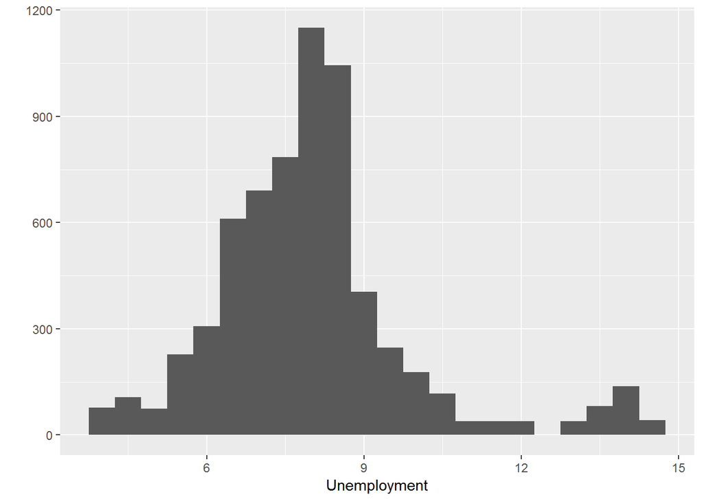

```
##    Min. 1st Qu.  Median    Mean 3rd Qu.    Max.
##   3.879   6.891   7.874   7.999   8.622  14.313
```

The Unemployment range from 3.8 to 14.3 . the high values may be outliers associated with extreme cases in certain regions.I wonder if the Unemployment has an effect on sales in that region.

### IsHoliday

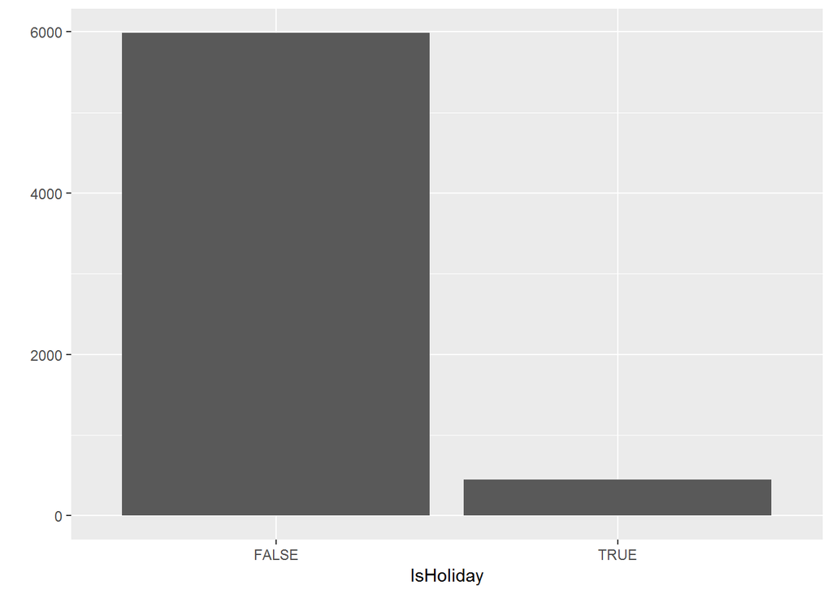

```
##    Mode   FALSE    TRUE
## logical    5985     450
```

there is only 450 holiday situations given that we have 45 stores that’s 10 weeks of holidays during our period of investigation

### Markdown:

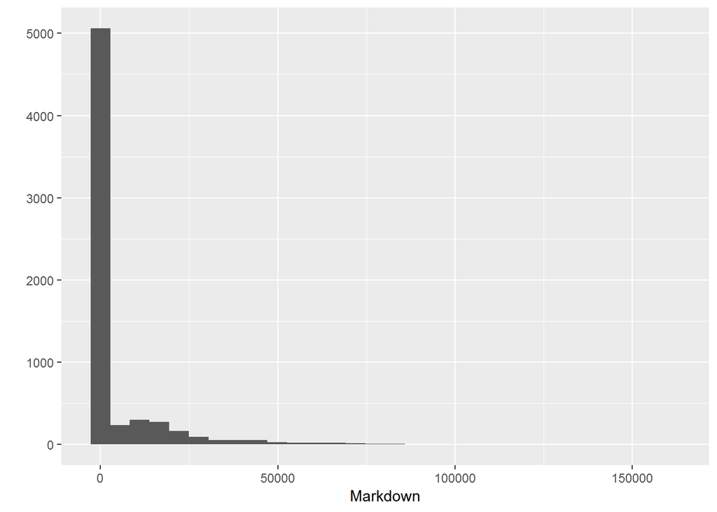

```
##    Min. 1st Qu.  Median    Mean 3rd Qu.    Max.
##       0       0       0    5072       0  160511
```

i think it is useful to execlude the situations where there is no markdown to get clearer view.

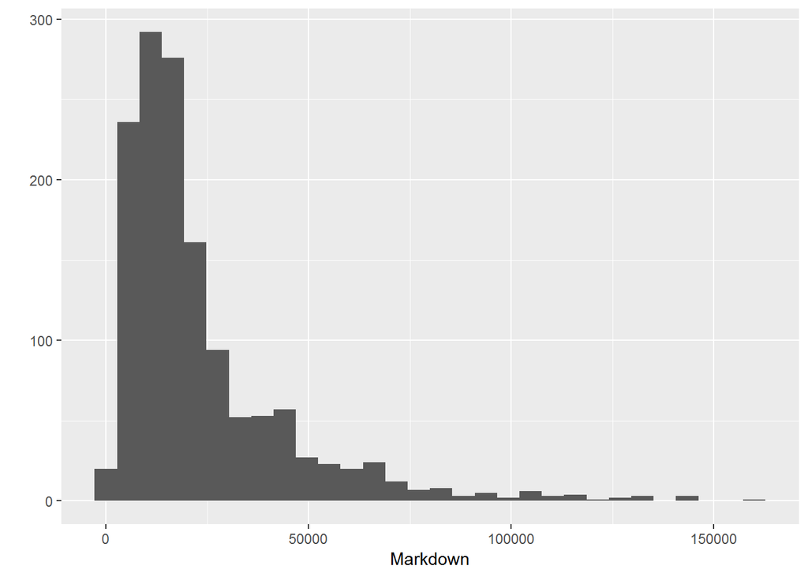

```
##     Min.  1st Qu.   Median     Mean  3rd Qu.     Max.
##    567.4   9831.7  16584.5  23398.1  28121.2 160510.6
```

the mark down varies from 567 to 160000 with most of the data below 50000 .

### Weekly_Sales:

the major variable in our data set.

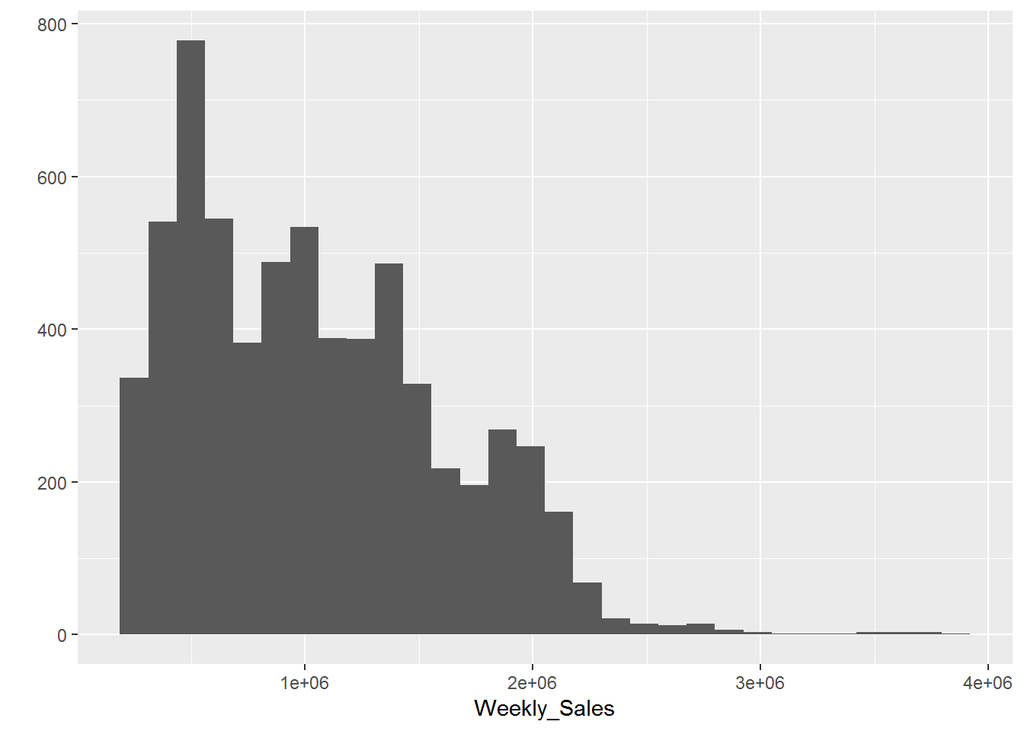

```
##    Min. 1st Qu.  Median    Mean 3rd Qu.    Max.
##  209986  553350  960746 1046965 1420159 3818686
```

the sales varies from 209k to 3818k .With most data below 2 millions.I Wonder what caused those high sales at the end.

# Univariate Analysis

### What is the structure of your dataset?

the data consists of 6435 obsevations of 11 variables

### What is/are the main feature(s) of interest in your dataset?

the mean feature of interest is the weekly_sales.We want to investigate what other parameters affect it and how

### What other features in the dataset do you think will help support your investigation into your feature(s) of interest?

all the other variables .I think all the other variables have a relation with sales and will investigate that in the next section

### Did you create any new variables from existing variables in the dataset?

YES,I summed all the markdowns in one column.

### Of the features you investigated, were there any unusual distributions? Did you perform any operations on the data to tidy, adjust, or change the form of the data? If so, why did you do this?

YEs, the data was provided in three files . I read them and joined them ,removed duplicated columns, changed some column names and data types and aggregated the weekly_sales . The code for this is provided at the beginning of the file.

# Bivariate Plots Section

let’s create a matrix plot for all the variables to determine relationships

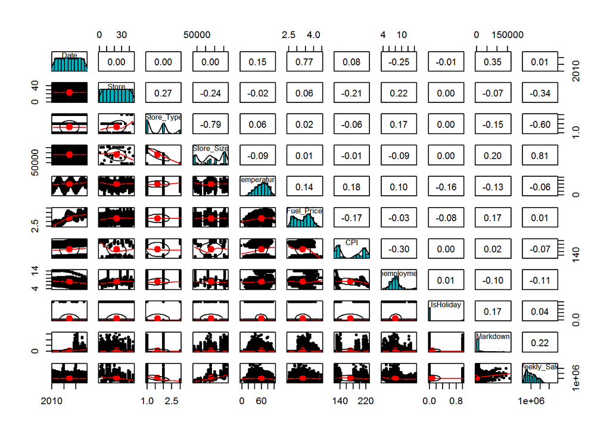

from the plot :

## let’s investigate more the sales related variables

### relation between sales and markdown

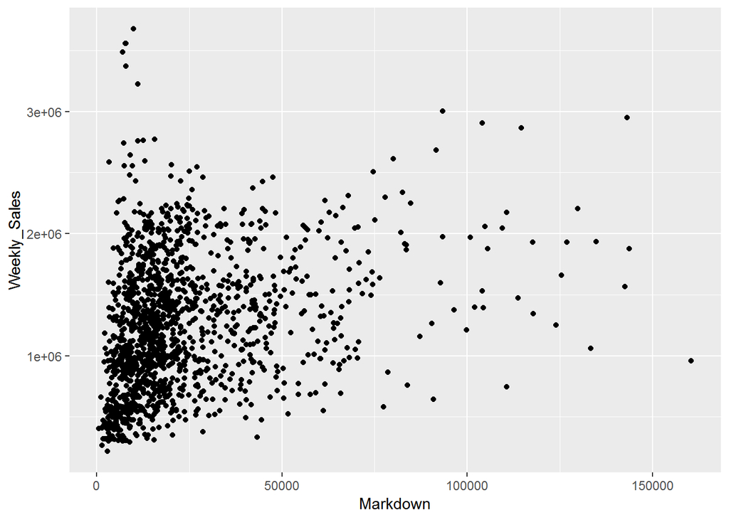

### relation between sales and holidays

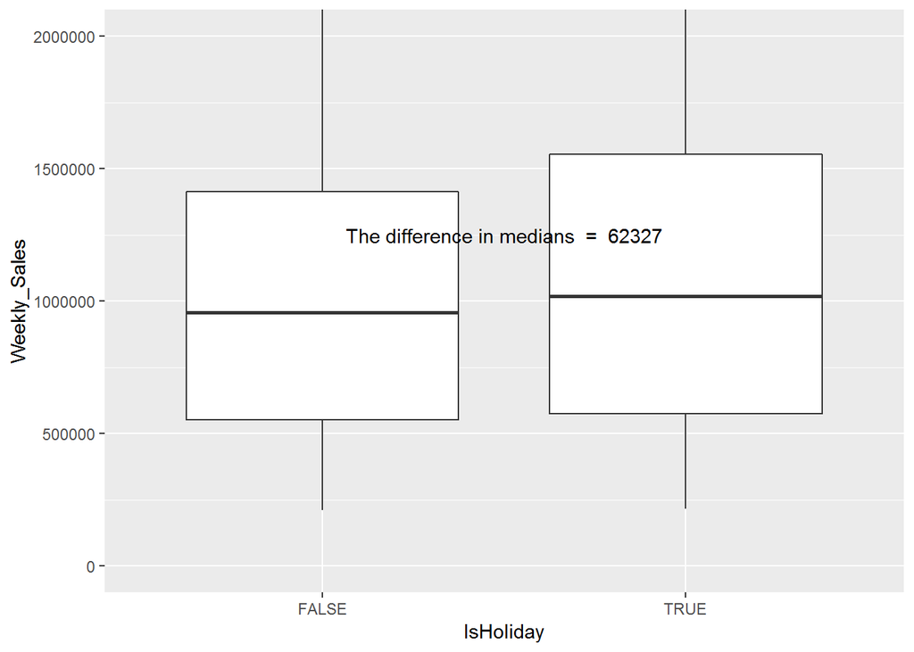

the holidays have larger sales than ordinary sales

note: I limited the y axis to 2 millions to clear the graph

### realtion between sales and unemployment

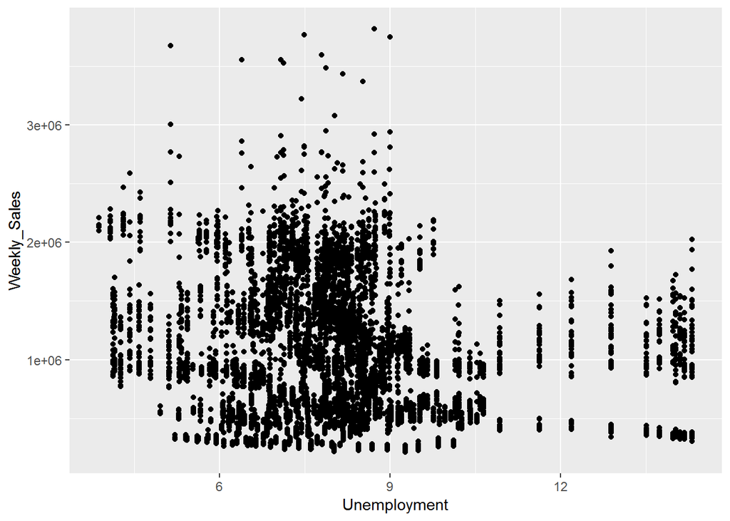

there is aweak relationship.but in general when unemployment increases to higher than 10 the sales decreases alittle

### realtion between sales and CPI

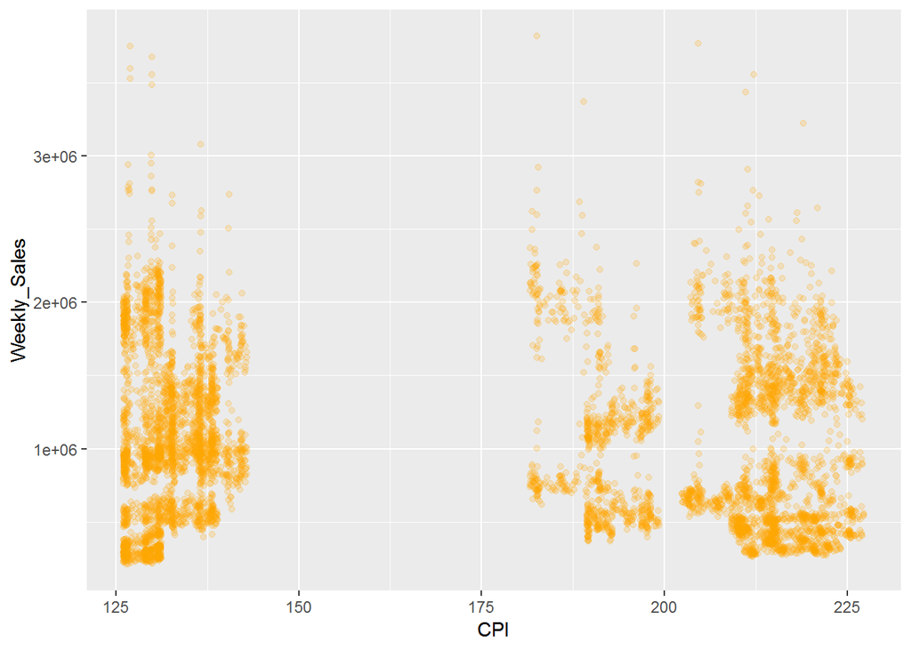

the graph indicates a very weak relationship

### realtion between sales and Fuel prce

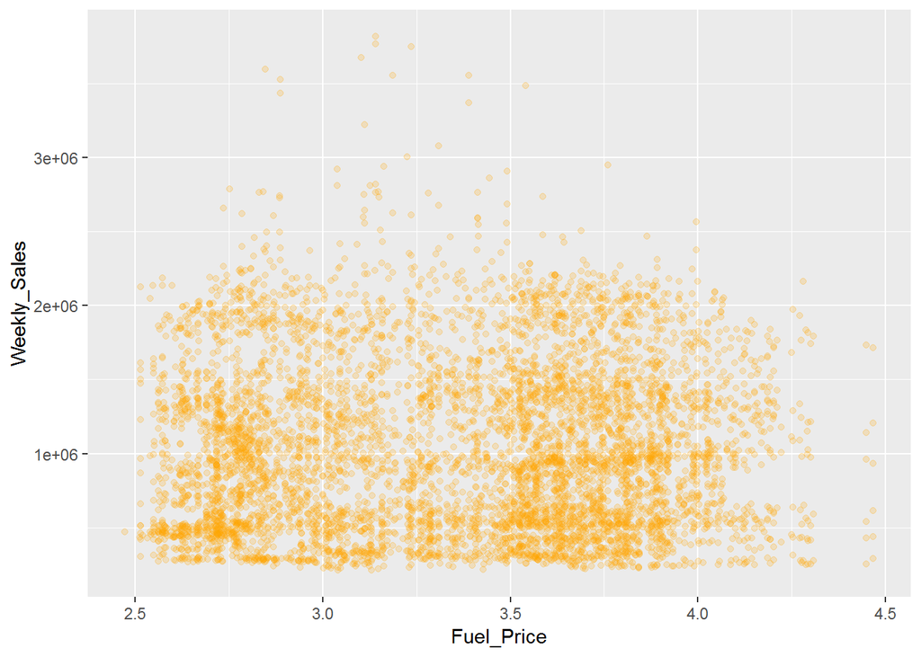

the graph indicates a very weak relationship

### realtion between sales and Temperature

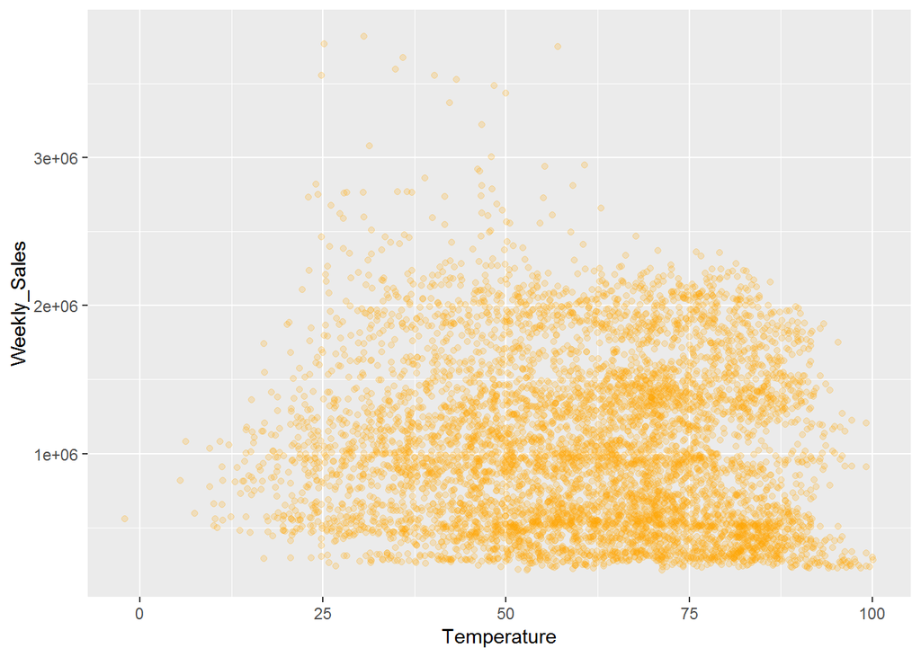

the graph indicates a very weak relationship

### realtion between sales and store size

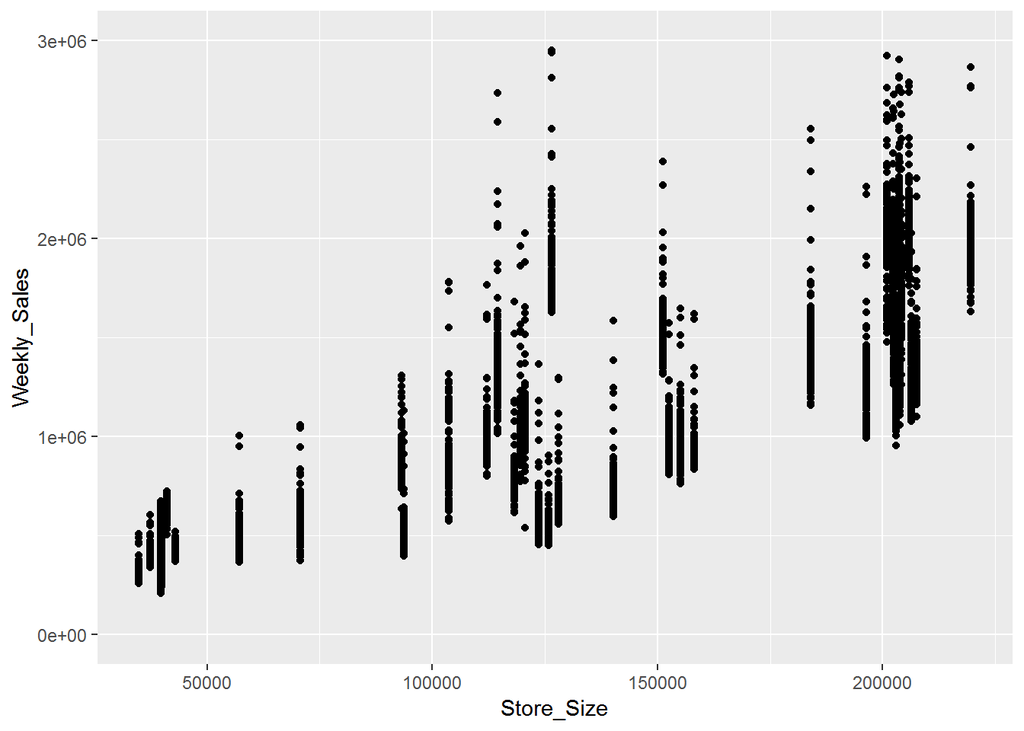

there is a positive relationship between store size and sales which is reasonable and expected

### realtion between sales and store type

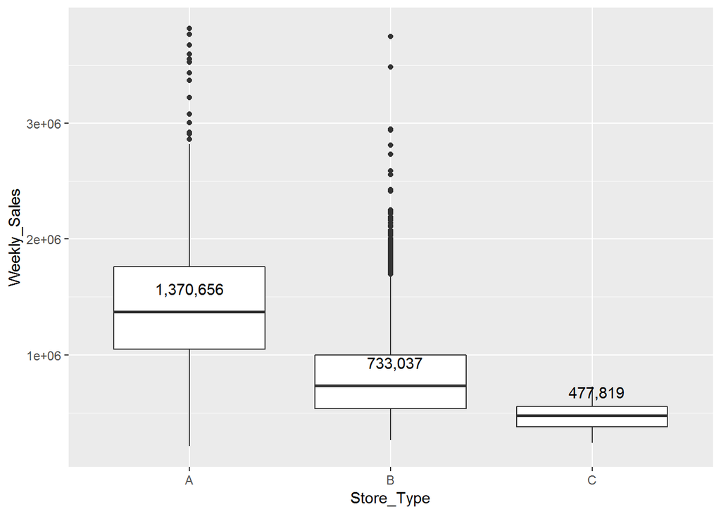

Despite we have small data about stores of class c, it is clear that sales of store A is the highest followed by store B the store C.

### relationship of sales over the year

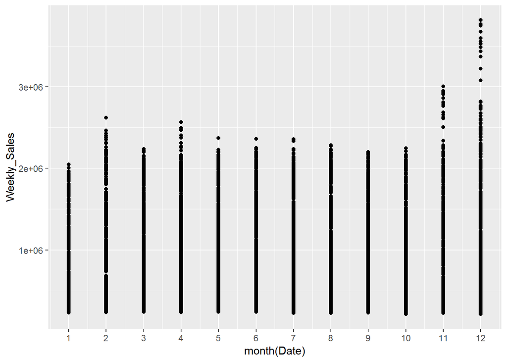

the sales vary through the year but significantly increases in the Christmas and Thanksgiving

## variables other than sales:

### the store type VS store size:

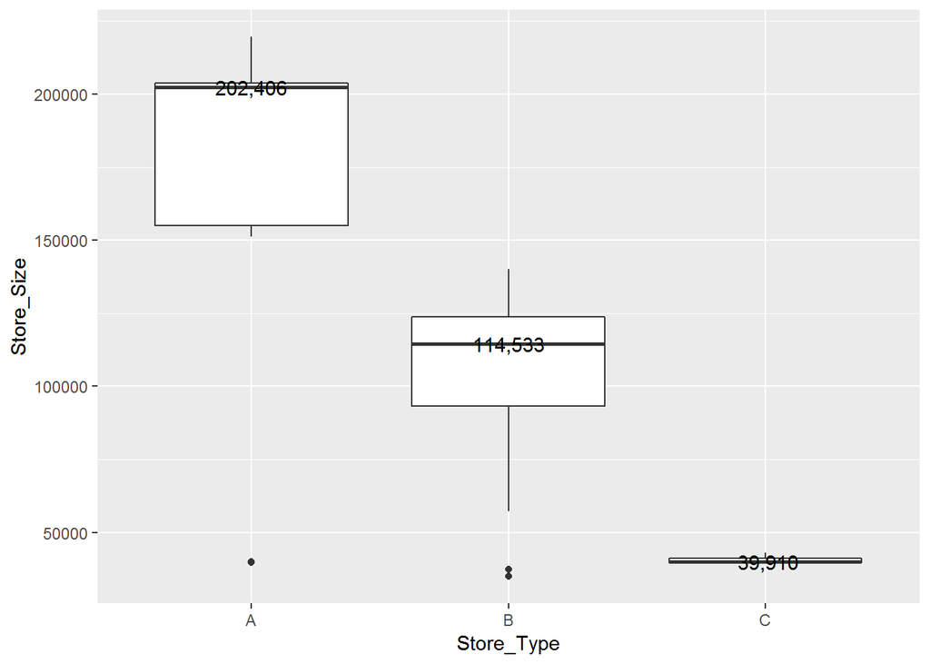

the stores with high rank tends to have larger size

### relationship of temperature over the year

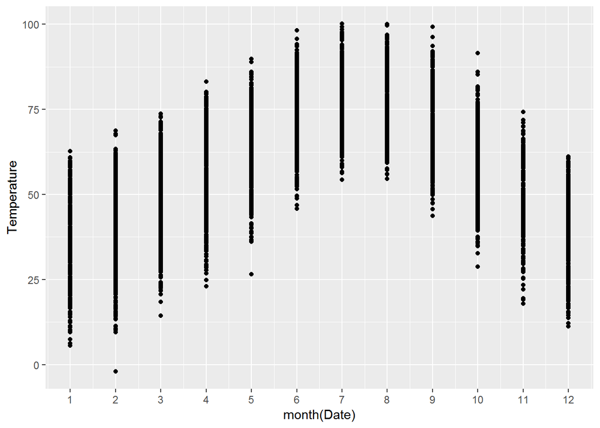

the temperature increases in summer and decreases in winter with different degrees in different locations

### relationship of fuel price over the year

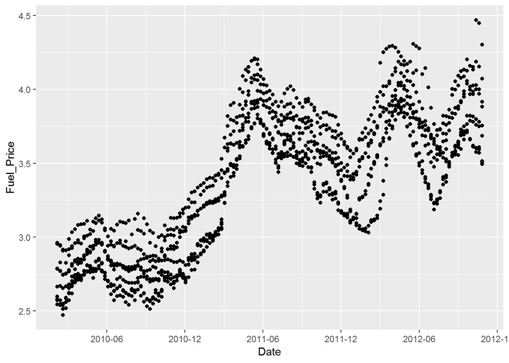

the fuel price is increasing with time with ups and downs from 2011

### relationship of CPI over the year

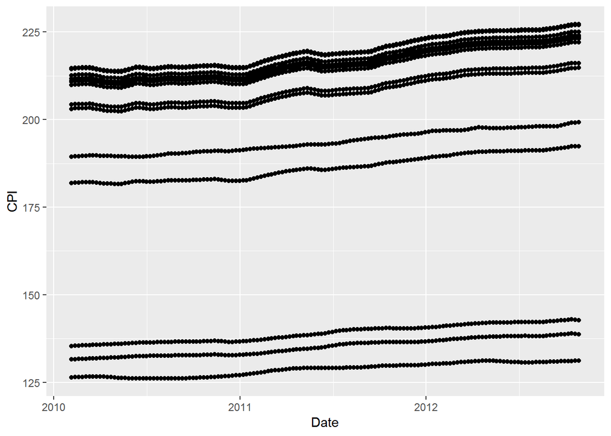

looks like CPI varies across regions but there is an increasing trend in all regions

### relationship of unemployment over the year

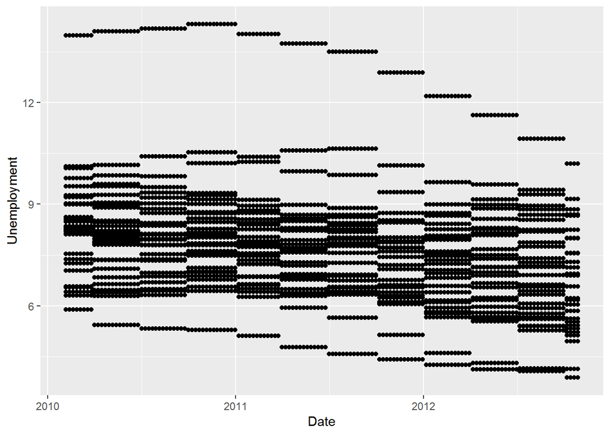

this plot is unclear I think it must be broken by region

### what holidays does this data account for

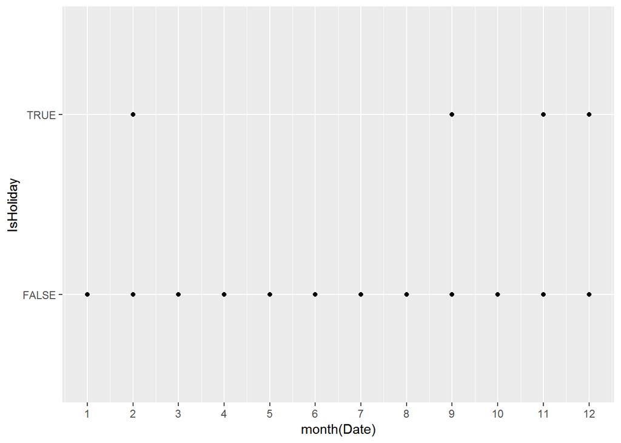

this data accounts for the Super Bowl,Labor Day,Thanksgiving and Christmas

### when are the markdowns

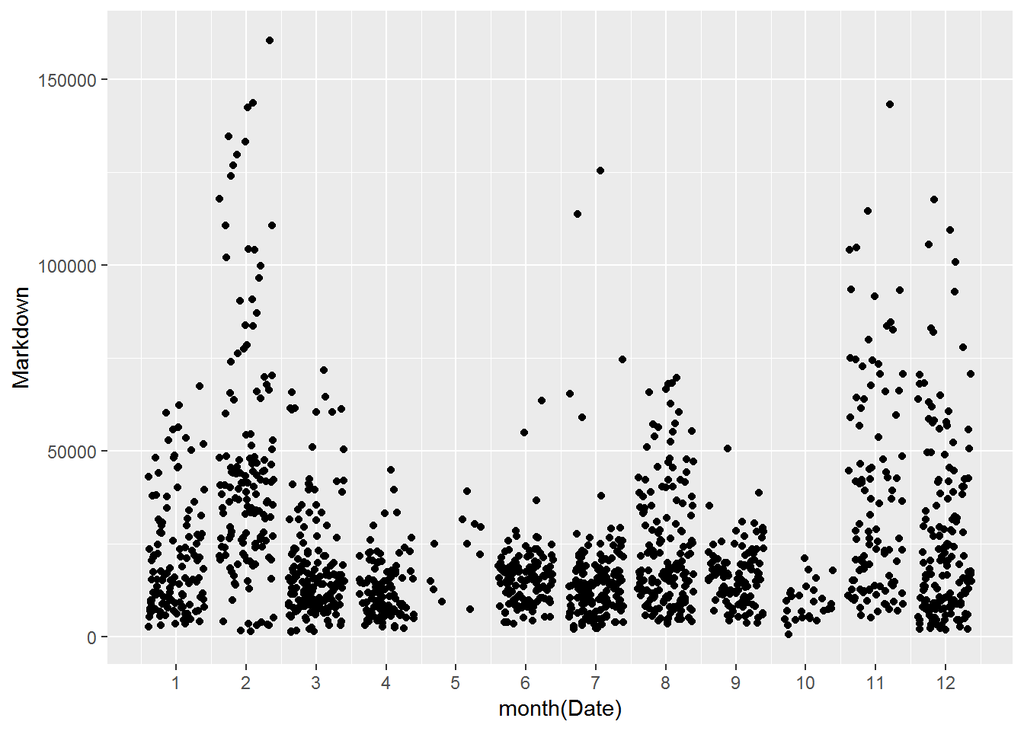

the markdowns frequently occur in feb ,nov and dec that is the Super Bowl,Thanksgiving and Christmas

# Bivariate Analysis

### Talk about some of the relationships you observed in this part of the investigation. How did the feature(s) of interest vary with other features in the dataset?

the key contributors to sales are the store size , store type and the markdown with small effect of unemployment

### Did you observe any interesting relationships between the other features (not the main feature(s) of interest)?

- the fuel price increased dramatically after 2011 with large fluctuations.
- the CPI is increasing by time
- the stores with higher grade tends to be bigger in size

### What was the strongest relationship you found?

the relationship between the weekly sales and the store size with correlation index of 0.81

# Multivariate Plots Section

### markdown with sales broken by store type

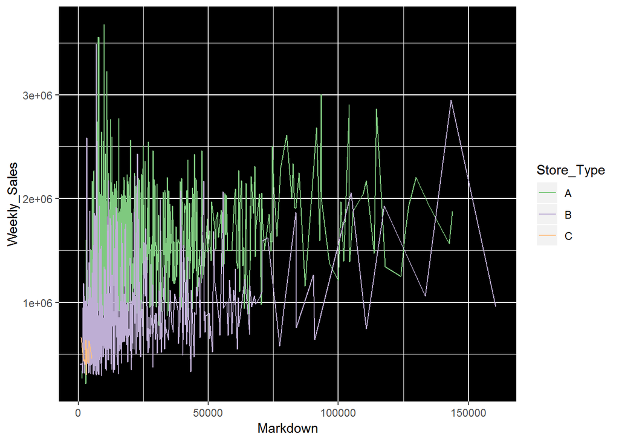

although there is not a clear trend here but the sales tends to be higher with small markdowns.May be it is because the large markdown actually lower the net sales amount . it would be useful if we have data about the quantity sold

> because we have 45 stores the plots will be un clear,so will take a subset of stores 2A stores,2B stores and 2C stores which are (1,2,9,10,37,38)

### unemployment with sales broken by store

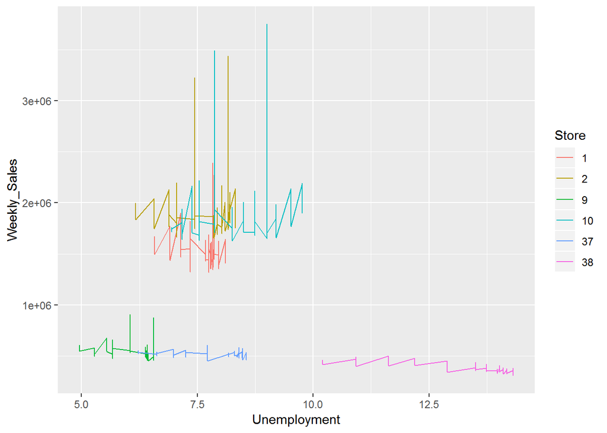

there is no trend of the unemployment with sales the large sales may be due to holidays

### fuel price with sales broken by store

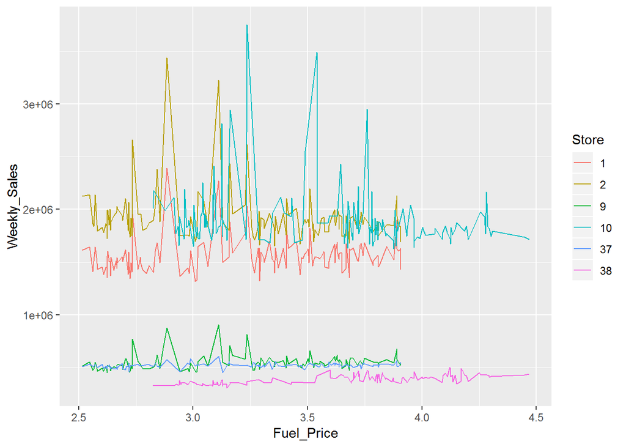

there is no trend of the fuel price with sales the large sales may be due to holidays

### temperature with sales broken by store

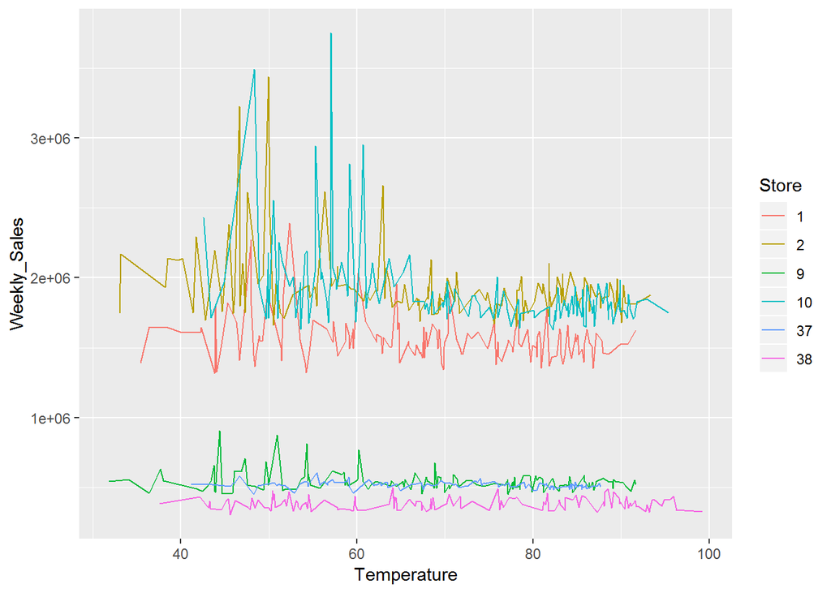

there is no trend of the temperature with sales the large sales may be due to holidays

### CPI with sales broken by store

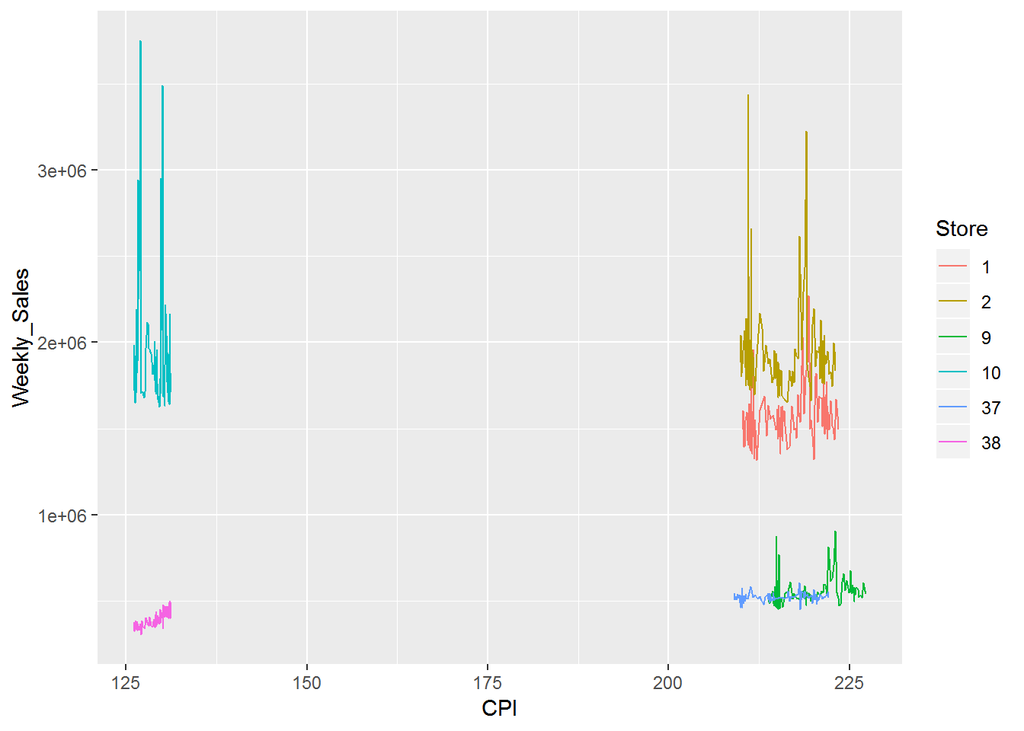

there is no trend of the CPI with sales the large sales may be due to holidays. Although there is a small increase in sales due to the increase of the price of goods